# CPLN 505 Assignment 2

Philadelphia is served by a combined sewer system and is currently considering efforts to improve it’s sewer system in a manner that will provide environmental and economic benefit to the city. We will look at the environmental and population data from different cities and facilities in the US and hopefully glean some useful information that we can use to guide Philadelphia’s decision

### **Section 1: Computing projected changes**

1. Projected change in residential population receiving collection
2. Projected percent change in residential population receiving collection
3. Projected change in residential population receiving treatment
4. Projected percent change in residential population receiving treatment
5. Projected change in non-residential population receiving treatment
6. Projected percent change in non-residential population receiving treatment
7. Projected change in non-residential population receiving collection
8. Projected percent change in non-residential population receiving collection
9. Residential population density (using county area and population)
10. Change and percent change in population density
11. Percent change in median income

### **Section 2: Provide summary statistics of test data**

Boxplots/ density plots by region

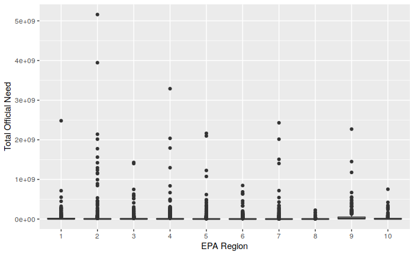

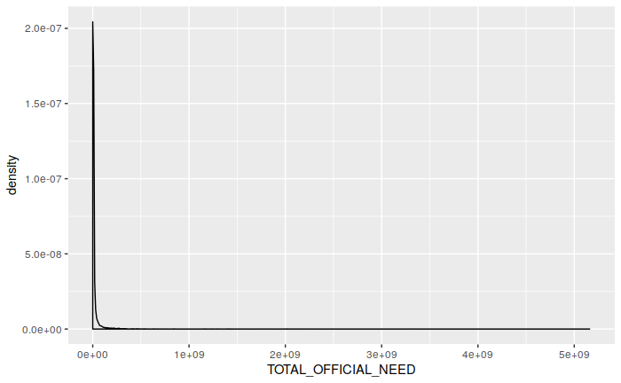

### **Section 3: Tests of association**

In this section we would want to see if there is some association between some of the categorical variables and the continous outputs.

#### **Part 1:**

The first association test will be between facilities’ total need with a combined sewer system (CSS) or with a Municipal Separate Sewer System(MS4s).

The summary data for facilities with MS4 is:

```
     Min.   1st Qu.    Median      Mean   3rd Qu.      Max.
0.000e+00 6.281e+05 2.162e+06 1.338e+07 6.708e+06 3.290e+09
```

The summary data for facilities with CSS is:

```
     Min.   1st Qu.    Median      Mean   3rd Qu.      Max.
0.000e+00 2.833e+06 8.814e+06 1.131e+08 3.625e+07 5.160e+09
```

A look at the mean and the median of the two categories indicates that facilities with combined sewer systems have a higher median, mean and maximum total official need. This could indicate that there is a bit of concern with systems that have combined sewer systems.

We will do a a t-test to see if there is a significance in the difference of the means off the two locales.

```
    Welch Two Sample t-test

data:  css_facilities_need and ms4_facilities_need
t = 6.712, df = 699.19, p-value = 3.972e-11
alternative hypothesis: true difference in means is not equal to 0
95 percent confidence interval:
  70514032 128823442
sample estimates:
mean of x mean of y
113053301  13384564
```

With a p-value that is well below the 0.01 threshold, we can reject the null hypothesis and infer that there difference in means of the two groups is statistically significant

#### **Part 2:**

We will then proceed to investigate if there is a significant difference between facilities’ need for those that are associated with a TMDL. Afterwards we will check if these vary by region.

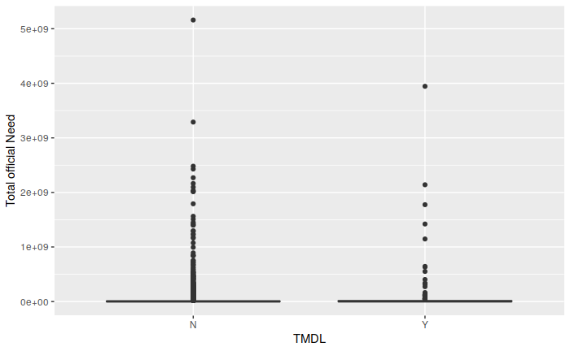

|  | summary_yes_tmdl |
| --- | --- |
| Min. | 0.000e+00 |
| 1st Qu. | 1.249e+06 |
| Median | 3.862e+06 |
| Mean | 5.900e+07 |
| 3rd Qu. | 1.437e+07 |
| Max. | 3.945e+09 |

|  | summary_no_tmdl |
| --- | --- |
| Min. | 0.000e+00 |
| 1st Qu. | 6.908e+05 |
| Median | 2.372e+06 |
| Mean | 2.023e+07 |
| 3rd Qu. | 7.537e+06 |
| Max. | 5.160e+09 |

The next step is to test if there is a significanct difference in the means. We can accomplish this using a t-test on the two quantities.

```
    Welch Two Sample t-test

data:  official_need_no_tmdl and official_need_yes_tmdl
t = -2.2283, df = 305.8, p-value = 0.02658
alternative hypothesis: true difference in means is not equal to 0
95 percent confidence interval:
 -73003450  -4533819
sample estimates:
mean of x mean of y
 20228097  58996731
```

We obtain a p-value of 0.02, therefore we can reject the null hypothesis and infer that the difference in the two means is significant. The next step is to see the manifestation of this difference by region.

```
    Welch Two Sample t-test

data:  region_yes_tmdl and region_no_tmdl
t = 0.85922, df = 3.0193, p-value = 0.453
alternative hypothesis: true difference in means is not equal to 0
95 percent confidence interval:
 -311336752  542766502
sample estimates:
mean of x mean of y
148400209  32685334


    Welch Two Sample t-test

data:  region_yes_tmdl and region_no_tmdl
t = 3.5245, df = 5.0045, p-value = 0.01681
alternative hypothesis: true difference in means is not equal to 0
95 percent confidence interval:
  475206220 3033874754
sample estimates:
 mean of x  mean of y
1794202835   39662349


    Welch Two Sample t-test

data:  region_yes_tmdl and region_no_tmdl
t = -2.6523, df = 31.104, p-value = 0.01247
alternative hypothesis: true difference in means is not equal to 0
95 percent confidence interval:
 -16806577  -2196333
sample estimates:
mean of x mean of y
  8902520  18403975


    Welch Two Sample t-test

data:  region_yes_tmdl and region_no_tmdl
t = -0.12885, df = 18.325, p-value = 0.8989
```

[output cut: 41 more lines]

```
sample estimates:
mean of x mean of y
181034656  65458334


    Welch Two Sample t-test

data:  region_yes_tmdl and region_no_tmdl
t = -1.2645, df = 252, p-value = 0.2072
alternative hypothesis: true difference in means is not equal to 0
95 percent confidence interval:
 -22511440   4907121
sample estimates:
mean of x mean of y
 17332528  26134688
```

### **Section 5: Conclusion and Recommendations**

From the data manipulation above, we can see that Philadelphia should implement a municipal separate sewer system.